# Reproducible Research

Non-Routine Cognitive Analytical Tasks (NRCA)

Author

Alain Kalonji

Published

June 22, 2025

# Theoretical Framework: Non-Routine Cognitive Analytical Tasks (NRCA)

The rise of Non-Routine Cognitive Analytical (NRCA) tasks is a direct manifestation of skill-biased technological change (Autor, Levy & Murnane, 2003). These tasks include:

- Analyzing complex information
- Solving problems
- Making strategic decisions
- Designing or interpreting abstract concepts

Unlike manual or routine tasks, these activities are neither easily automated nor easily replaced by algorithms. They have therefore become increasingly central in advanced economies, particularly in the context of the growing digitization of work.

> 📚 **References**: Autor, D., Levy, F., & Murnane, R. (2003). *The Skill Content of Recent Technological Change: An Empirical Exploration*. The Quarterly Journal of Economics, 118(4), 1279–1333. Goos, M., & Manning, A. (2007). *Lousy and Lovely Jobs: The Rising Polarization of Work in Britain*. Review of Economics and Statistics, 89(1), 118–133. OECD (2019). *OECD Employment Outlook 2019: The Future of Work*.

# 📈 Graph Interpretation: NRCA Task Intensity (2011–2020)

This chart shows the standardized evolution of NRCA task intensity in four European countries: **Czechia, Denmark, Italy**, and **EU-28**, between the first quarter of 2011 and the fourth quarter of 2020.

[figure not shown]

Evolution of NRCA Task Intensity

# Limitations and Future Directions

- **Missing data**: Some values are missing for the EU after 2019.
- **Polarization**: Consider comparing with the evolution of routine tasks (RoutineManual).
- **Automation**: Results could be linked with indicators of technological adoption.

# Conclusion

The graph confirms a structural trend in the European labor market: a rise in non-routine analytical skills, which are key drivers of employability in a digital world.

This reinforces the idea that **education**, **continuous training**, and **adaptation of production systems** are essential levers to promote the adoption of these high-value tasks.

### R Code (hidden by default)

# Data Preparation and Processing

## 1. Load ISCO Data (ISCO1 to ISCO9)

#2. Select 4 Countries (excluding Belgium, Spain, Poland, France)

# 3. Compute Employment Shares per Country

# 4. Load O*NET Task Data and Aggregate by ISCO Level 1

# 5. Define Task Groups

# 6. Standardize and Compute Indices

# 7. Compare NRCA Intensity Across Countries

# 8. Multi-Country Visualization with ggplot2

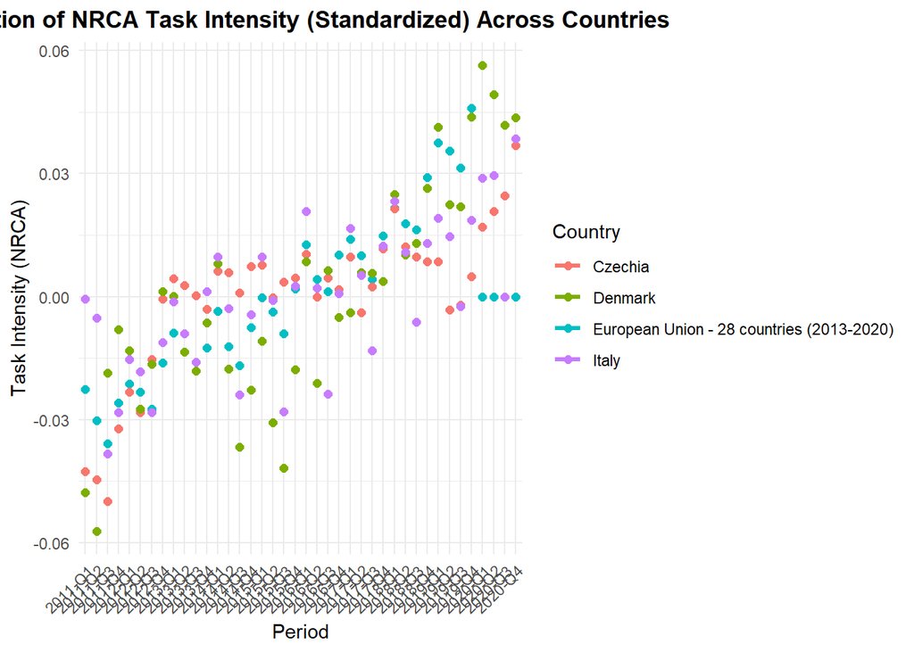